# Impresora 3D

Una impresora 3D produce planchas de 25 piezas plásticas idénticas.

Los diseños de las piezas tienen complejidad variable y de esa complejidad depende la probabilidad que una pieza tenga defectos al imprimirse.

Se quieren comprender los distintos aspectos relacionados con los defectos en la fabricación de las piezas.

# Preliminares

Un estudio previo determinó que se puede suponer que las piezas impresas en una misma plancha son independientes entre sí y que las planchas también son independientes entre sí, siempre que se sigan las recomendaciones de mantenimiento y calibración.

Ese mismo estudio determinó las siguientes probabilidades de defecto por pieza dado el nivel de complejidad de la misma.

En la tabla, **Comp** corresponde a los niveles de complejidad del diseño. La complejidad del diseño es una variable categórica ordinal y trabajamos con: Baja < Media < Alta.

En la tabla, **ProbError** corresponde a la probabilidad condicional de que una pieza sea defectuosa dado el nivel de complejidad especificado.

En la tabla, **Prod** corresponde a la proporción del total de la producción de la impresora que se dedica a planchas del nivel de complejidad especificado.

| Comp | ProbError | Prod |
| --- | --- | --- |
| Baja | 0.02 | 0.27 |
| Media | 0.15 | 0.36 |
| Alta | 0.31 | 0.37 |

# Datos del segundo estudio

Para un nuevo estudio se han recolectado datos sobre 10000 planchas impresas y el número de piezas defectuosas por plancha; la impresora se mantuvo bien mantenida y calibrada a lo largo del estudio por lo que se espera que los datos reflejen la realidad del modelo teórico que se quiere plantear.

El máximo número de piezas defectuosas por plancha fue 17 y casi el 80 % de las planchas estudiadas tienen a lo mucho 7 piezas defectuosas; casi el 55 % de las planchas tienen a lo mucho 4 piezas defectuosas.

Aproximadamente el 17 % de las planchas no tienen piezas defectuosas.

El promedio de piezas defectuosas es 4.34 y su desviación estándar es 3.43, por lo que el coeficiente de variación del número de piezas defectuosas es 0.79 y podemos decir que el número de piezas defectuosas está ligeramente sesgado a la derecha y relativamente disperso alrededor de su media.

Algunos de estos resultados se pueden apreciar en las siguientes gráficas.

## Gráficas

Primero queremos estudiar el número de piezas defectuosas por plancha.

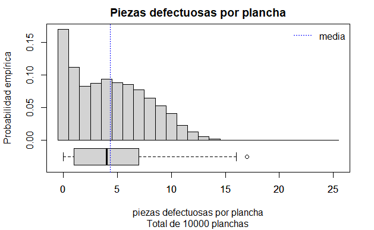

La variable aleatoria que cuenta el número de defectos por plancha es peculiar y no se ajusta directamente a ninguno de los modelos estándar. Su rango es claramente el conjunto de los enteros entre 0 y 25, pues una plancha podría tener cualquier cantidad de piezas defectuosas, desde ninguna (0 piezas defectuosas) hasta todas (25 piezas defectuosas).

Son de particular interés las clases correspondientes a 0 y 4 defectos.

Suponemos, gracias al número de observaciones, que esa *bimodalidad* aparente es real y no debida simplemente a las fluctuaciones aleatorias de la muestra.

# Dependencias

En la siguiente gráfica podemos apreciar que el número de piezas defectuosas por plancha depende claramente de la complejidad del diseño de la pieza.

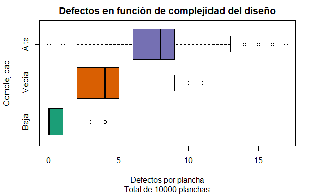

Los histogramas de el número de piezas por complejidad del diseño se ven un poco más familiares y sirven para explicar la *bimodalidad* que mencionamos previamente.

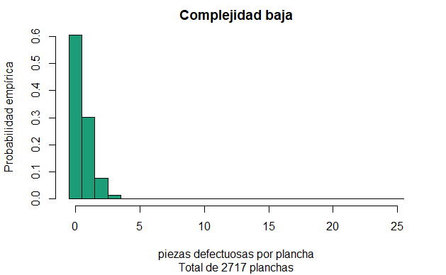

Las planchas de complejidad baja tienen una probabilidad pequeña de generar piezas con defectos, pero también son, relativas al total de planchas que se producen, el grupo menos numeroso.

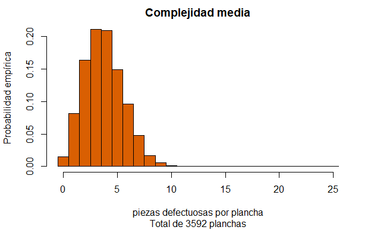

Las planchas de complejidad media tienen una mayor probabilidad de generar piezas con defectos.

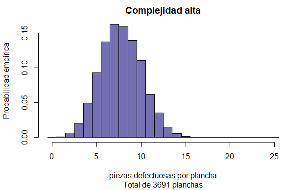

Las planchas de complejidad alta tienen la probabilidad más grande de generar piezas con defectos. Son el grupo más numeroso de planchas que se producen aunque en cantidad sean similar al grupo de complejidad media.

Si superponemos los histogramas podemos entender el histograma *bimodal* del principio.

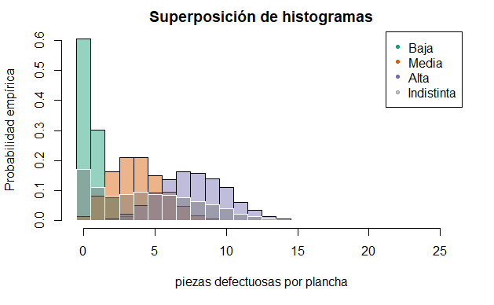

## Probabilidades condicionales

Como se puede apreciar que el número de piezas defectuosas parece depender de la complejidad del diseño de la plancha que se imprime, puede ser interesante calcular las probabilidades condicionales empíricas de la complejidad para cada cantidad de piezas defectuosas.

Las probabilidades empíricas son aquellas que se obtienen a partir de la muestra tomando la proporción de casos favorables al evento que queremos estudiar, entre casos totales, todo esto dentro del universo de interés.

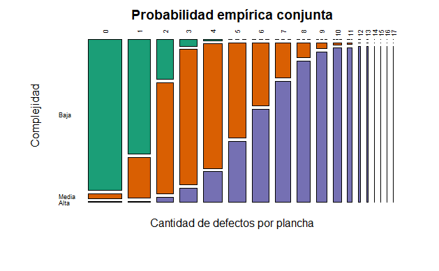

Este mosaico muestra gráficamente las probabilidades de las diversas combinaciones de número de defectos por planchas y complejidad. Por ejemplo, el rectángulo grande verde corresponde la probabilidad empírica de que una plancha sea de *complejidad baja y tenga cero defectos*. Esa probabilidad es aproximadamente 0.16. Es importante recordar que el “área” del mosaico es 1 y que los diversos rectángulos corresponden a las distintas proporciones o probabilidades.

Finalmente, podemos adaptar el gráfico anterior para tener una idea visual de las probabilidades condicionales empíricas (calculadas de la muestra).

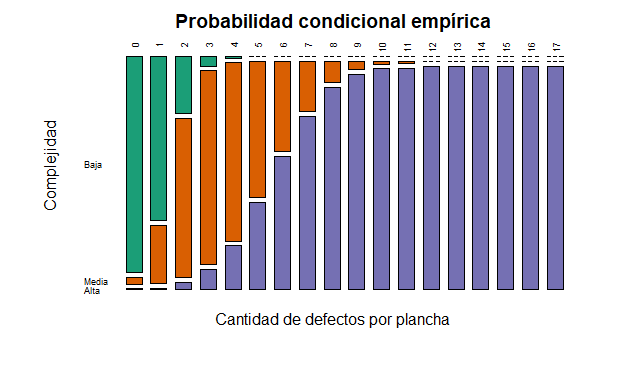

Por ejemplo, si nos concentramos en la columna correspondiente a seis defectos, podemos apreciar claramente que la probabilidad condicional de que la plancha sea de complejidad alta es bastante mayor a un medio, mientras que la probabilidad de que la plancha sea de complejidad baja es cero.

Claramente estos resultados corresponden a las probabilidades empíricas, calculadas directamente desde la muestra.

Los valores teóricos de dicha probabilidad se pueden calcular usando el teorema de Bayes.